# Feather River - Mini Snorkel Hypothesis-Testing Models of Fish Occurrence

Maddee Wiggins (FlowWest)

2026-10-20

**DRAFT.** This document restructures the Chinook/steelhead mixed-model analysis (feather_river_cover_analysis_salmon.Rmd) into a set of pre-specified competing models.

## Objective

Test which of several hypotheses about habitat best explains fish presence/absence in the Feather River mini snorkel data (2001-2002), using AICc to compare a fixed set of models rather than selecting terms stepwise.

## Approach

- **Response:** presence/absence of the target species in a microhabitat unit (one row per `micro_hab_data_tbl_id`). Units where only other species were seen are absences of the target species.
- **Predictors:** only variables recorded for every unit, so absences are kept. Fish-only variables (`fl_mm`, `dist_to_bottom`, `focal_velocity`) are excluded.
- **Cover:** a single 0/1 variable. Percent cover from the Habitat Accounting (HA) cover categories is combined, and a unit has cover if the combined percent is at least the threshold (20%). The classification is a standalone function, ha_cover.R, so the categories, columns, threshold and combination rule can be changed without editing this document.
- **Models:** binomial GLMs fit on identical rows. Models 1-7 are the habitat hypotheses. Models 8-10 add redd count, season (month) or sampling design to the best of models 1-7.
- **Evaluation:** AICc, delta AICc and Akaike weights; odds ratios for the best model; leave-one-site-out cross-validated AUC.
- **Robustness:** the whole set is refit with a survey-event random intercept because about 36 units are sampled per survey.

Species: chinook. Cover threshold: 20% (categories combined by sum).

## Data

Mini snorkel data are read from local copies of edi.1705.2 in `mini-snorkel-analysis/data-raw`. Redd data are read from `edi-redd/data` (the EDI package for the redd data, edi.1802.2, was not publicly readable when this draft was written).

```r
fish_raw <- read_csv(here("mini-snorkel-analysis", "data-raw", "microhabitat_observations.csv"),
                     show_col_types = FALSE)
locations_raw <- read_csv(here("mini-snorkel-analysis", "data-raw", "survey_locations.csv"),
                          show_col_types = FALSE)
redd_raw <- read_csv(here("edi-redd", "data", "redd_observations.csv"), show_col_types = FALSE)
```

### Survey attributes

`survey_locations.csv` has more than one row for some surveys (`location_table_id`), which differ only in their coordinates. Joining it directly to the fish data would duplicate every unit at those surveys, so survey attributes are collapsed to one row per survey. The coordinate variants are kept in `locations_raw` for matching redds to transects.

```r
survey_attrs <- locations_raw |>
  select(-latitude, -longitude, -coordinate_method) |>
  distinct()

stopifnot(!anyDuplicated(survey_attrs$location_table_id))

tibble(location_rows = nrow(locations_raw), surveys = nrow(survey_attrs)) |>
  knitr::kable(caption = "Rows in survey_locations.csv vs. surveys")
```

Rows in survey_locations.csv vs. surveys

| location_rows | surveys |
| --- | --- |
| 580 | 267 |

### Collapse to one row per microhabitat unit

Fish-level rows are summed to the unit. Counts of other species do not make a unit a presence for the target species.

```r
unit_vars <- c("location_table_id", "date", "transect_code", "depth", "velocity",
               "surface_turbidity", "channel_geomorphic_unit",
               "percent_small_woody_cover_inchannel", "percent_large_woody_cover_inchannel",
               "percent_submerged_aquatic_veg_inchannel", "percent_undercut_bank",
               "percent_cover_half_meter_overhead", "percent_cover_more_than_half_meter_overhead",
               "percent_boulder_substrate")

# Check that unit-level covariates really are constant within a unit
unit_consistency <- fish_raw |>
  group_by(micro_hab_data_tbl_id) |>
  summarise(across(all_of(unit_vars), n_distinct), .groups = "drop") |>
  summarise(across(all_of(unit_vars), ~ sum(.x > 1)))
stopifnot(all(unit_consistency == 0))

units <- fish_raw |>
  group_by(micro_hab_data_tbl_id) |>
  summarise(
    target_count = sum(count[str_detect(species, params$species_pattern) & !is.na(species)],
                       na.rm = TRUE),
    across(all_of(unit_vars), first),
    .groups = "drop"
  ) |>
  mutate(presence = as.integer(target_count > 0)) |>
  left_join(survey_attrs, by = c("location_table_id", "date"))

stopifnot(nrow(units) == n_distinct(fish_raw$micro_hab_data_tbl_id))

units |>
  summarise(units = n(), presences = sum(presence), absences = sum(presence == 0),
            prevalence = round(mean(presence), 3)) |>
  knitr::kable(caption = "Units and presences of the target species")
```

Units and presences of the target species

| units | presences | absences | prevalence |
| --- | --- | --- | --- |
| 9609 | 236 | 9373 | 0.025 |

### Factor coding

```r
units <- units |>
  mutate(
    month = factor(month(date)),
    channel_location = factor(channel_location),
    channel_geomorphic_unit = factor(channel_geomorphic_unit),
    location = factor(location),
    location_table_id = factor(location_table_id)
  )
```

### Cover: one variable from the HA categories

The Habitat Accounting protocol treats cover as a qualifying criterion for rearing habitat: if at least 20% of the area includes cover features (habitat suitability index of at least 0.5), the area counts as rearing habitat (Appendix F, section 2.1.3.5). The 20% applies to cover features **together**, not to each type separately. This replaces the earlier approach of five separate 0/1 variables, so the cover hypothesis is a single term and models read as `cover + depth + velocity + other`.

`classify_ha_cover()` in ha_cover.R does this:

1. For each HA category, add the percent from its data column(s), capped at 100.
2. Combine the categories (`"sum"` by default, or `"max"`).
3. `cover = 1` if the combined percent is at least the threshold, otherwise 0. The continuous combined percent is kept as `cover_pct`.

The mapping from HA categories to mini snorkel columns is `ha_cover_map`:

```r
source(here("mini-snorkel-analysis", "analysis", "ha_cover.R"))

ha_cover_map |>
  group_by(ha_category) |>
  summarise(columns = paste(column, collapse = " + ")) |>
  knitr::kable(caption = "HA cover categories and the mini snorkel columns used (edit ha_cover_map in ha_cover.R)")
```

HA cover categories and the mini snorkel columns used (edit ha_cover_map in ha_cover.R)

| ha_category | columns |
| --- | --- |
| aquatic_vegetation | percent_submerged_aquatic_veg_inchannel |
| boulder | percent_boulder_substrate |
| overhanging_vegetation | percent_cover_half_meter_overhead + percent_cover_more_than_half_meter_overhead |
| root_wad_logjam_large_wood | percent_large_woody_cover_inchannel |
| undercut_bank | percent_undercut_bank |
| woody_debris | percent_small_woody_cover_inchannel |

The categories are those the State Water Board lists for Table 28 of the protocol (woody debris, boulder, grass/herbaceous, willow and other riparian vegetation, undercut bank, aquatic vegetation, overhanging vegetation, root wad/logjam/large wood). Grass/herbaceous and willow/riparian vegetation have no matching column in the mini snorkel data. Cobble is not cover under HA, so it is excluded. Undercut bank in HA must be at least 0.5 ft, which the survey did not record.

```r
# Edit to change which HA categories count as cover, e.g.
# cover_use <- setdiff(unique(ha_cover_map$ha_category), "boulder")
cover_use <- unique(ha_cover_map$ha_category)

units <- classify_ha_cover(units,
                           threshold = params$percent_threshold,
                           use = cover_use,
                           method = params$cover_method,
                           keep_categories = TRUE)

cover_cols <- ha_cover_map$column[ha_cover_map$ha_category %in% cover_use]
```

```r
tibble(
  n_units = nrow(units),
  with_cover = sum(units$cover, na.rm = TRUE),
  pct_with_cover = round(100 * mean(units$cover, na.rm = TRUE), 1),
  missing_cover = sum(is.na(units$cover))
) |>
  knitr::kable(caption = "Units classified as having cover")
```

Units classified as having cover

| n_units | with_cover | pct_with_cover | missing_cover |
| --- | --- | --- | --- |
| 9609 | 4368 | 45.5 | 2 |

```r
units |>
  filter(!is.na(cover)) |>
  group_by(presence = ifelse(presence == 1, "target species present", "absent")) |>
  summarise(units = n(), pct_with_cover = round(100 * mean(cover), 1)) |>
  knitr::kable(caption = "Share of units with cover, by fish presence (raw, no model)")
```

Share of units with cover, by fish presence (raw, no model)

| presence | units | pct_with_cover |
| --- | --- | --- |
| absent | 9372 | 45.1 |
| target species present | 235 | 58.7 |

```r
units |>
  select(starts_with("ha_") & ends_with("_pct")) |>
  pivot_longer(everything(), names_to = "ha_category", values_to = "pct") |>
  group_by(ha_category) |>
  summarise(pct_units_nonzero = round(100 * mean(pct > 0, na.rm = TRUE), 1),
            mean_pct_when_present = round(mean(pct[pct > 0], na.rm = TRUE), 1)) |>
  knitr::kable(caption = "How often each HA category is recorded, and its mean percent when recorded")
```

How often each HA category is recorded, and its mean percent when recorded

| ha_category | pct_units_nonzero | mean_pct_when_present |
| --- | --- | --- |
| ha_aquatic_vegetation_pct | 42.7 | 33.4 |
| ha_boulder_pct | 10.1 | 25.0 |
| ha_overhanging_vegetation_pct | 24.6 | 43.4 |
| ha_root_wad_logjam_large_wood_pct | 1.0 | 26.7 |
| ha_undercut_bank_pct | 1.4 | 17.8 |
| ha_woody_debris_pct | 18.3 | 19.6 |

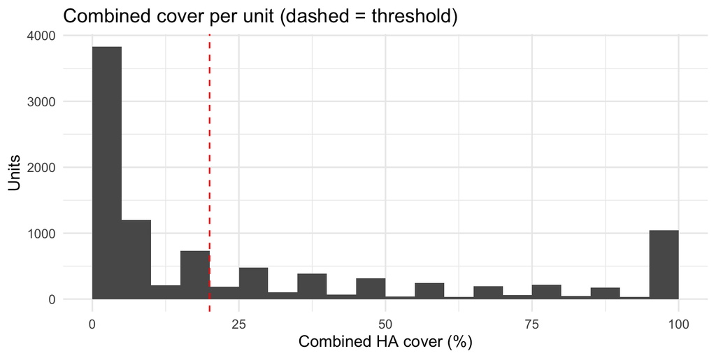

```r
units |>
  filter(!is.na(cover_pct)) |>
  ggplot(aes(cover_pct)) +
  geom_histogram(binwidth = 5, boundary = 0) +
  geom_vline(xintercept = params$percent_threshold, linetype = 2, color = "red") +
  labs(x = "Combined HA cover (%)", y = "Units",
       title = "Combined cover per unit (dashed = threshold)")
```

### Predictor standardization

Continuous predictors are standardized (`_z`, per 1 SD) in the model data so odds ratios are comparable.

### Redd count

Redds are matched to the nearest mini snorkel transect point within 50 m and summed by transect location. Redd data are 2014-2023 and the snorkel data are 2001-2002, so redd count is a site-level index of spawning use, not a year-matched value. It is constant within a site.

```r
site_pts <- locations_raw |>
  filter(!is.na(latitude), !is.na(longitude)) |>
  distinct(location, latitude, longitude) |>
  st_as_sf(coords = c("longitude", "latitude"), crs = 4326) |>
  st_transform(26910)

redd_pts <- redd_raw |>
  filter(number_redds > 0, !is.na(longitude), !is.na(latitude)) |>
  st_as_sf(coords = c("longitude", "latitude"), crs = 4326) |>
  st_transform(26910)

nearest <- st_nearest_feature(redd_pts, site_pts)

redd_by_site <- redd_pts |>
  st_drop_geometry() |>
  mutate(site = site_pts$location[nearest],
         dist_m = as.numeric(st_distance(redd_pts, site_pts[nearest, ], by_element = TRUE))) |>
  filter(dist_m <= params$redd_max_dist_m) |>
  group_by(location = site) |>
  summarise(redd_total = sum(number_redds), .groups = "drop")

units <- units |>
  left_join(redd_by_site, by = "location") |>
  mutate(redd_total = replace_na(redd_total, 0))

tibble(
  redds_total = sum(redd_pts$number_redds),
  redds_matched = sum(redd_by_site$redd_total),
  sites_with_redds = nrow(redd_by_site),
  sites_total = n_distinct(units$location)
) |>
  knitr::kable(caption = "Redds matched to mini snorkel transect locations")
```

Redds matched to mini snorkel transect locations

| redds_total | redds_matched | sites_with_redds | sites_total |
| --- | --- | --- | --- |
| 36880 | 9436 | 19 | 29 |

### Model data

Complete cases are taken **once**, on the union of variables used by any model, so every model is fit to the same rows. The table shows what is lost.

```r
needed <- c("presence", "location", "location_table_id", "channel_location",
            "channel_geomorphic_unit", "number_of_divers", "month",
            "depth", "velocity", "surface_turbidity", "cover", "cover_pct",
            cover_cols,   # raw percent columns, kept for the cover sensitivity checks
            if (params$use_redd) "redd_total",
            if (params$include_optional) "flow")

missing_summary <- units |>
  select(all_of(needed)) |>
  summarise(across(everything(), ~ sum(is.na(.x)))) |>
  pivot_longer(everything(), names_to = "variable", values_to = "n_missing") |>
  filter(n_missing > 0)

if (nrow(missing_summary) > 0) {
  knitr::kable(missing_summary, caption = "Units with missing values by variable")
}
```

Units with missing values by variable

| variable | n_missing |
| --- | --- |
| channel_geomorphic_unit | 797 |
| depth | 1 |
| velocity | 428 |
| surface_turbidity | 108 |
| cover | 2 |
| cover_pct | 2 |
| percent_large_woody_cover_inchannel | 1 |
| percent_boulder_substrate | 1 |

```r
zscore <- function(x) as.numeric(scale(x))

model_data <- units |>
  select(all_of(needed)) |>
  drop_na() |>
  droplevels() |>
  mutate(cover_pct_z = zscore(cover_pct),
         depth_z = zscore(depth),
         velocity_z = zscore(velocity),
         surface_turbidity_z = zscore(surface_turbidity),
         redd_z = if (params$use_redd) zscore(redd_total) else NA_real_,
         flow_z = if (params$include_optional) zscore(flow) else NA_real_,
         number_of_divers = factor(number_of_divers))

tibble(step = c("Units", "Complete cases on all model variables"),
       n = c(nrow(units), nrow(model_data)),
       presences = c(sum(units$presence), sum(model_data$presence)),
       absences = c(sum(units$presence == 0), sum(model_data$presence == 0))) |>
  knitr::kable(caption = "Rows retained for modeling")
```

Rows retained for modeling

| step | n | presences | absences |
| --- | --- | --- | --- |
| Units | 9609 | 236 | 9373 |
| Complete cases on all model variables | 8415 | 223 | 8192 |

## Candidate models

```r
cover_rhs <- "cover"          # combined HA cover, 0/1
cover_rhs_pct <- "cover_pct_z"  # combined HA cover, continuous (sensitivity)

add_term <- function(rhs, x) if (rhs == "1") x else paste(rhs, "+", x)

stage1_specs <- function(cover_rhs) {
  specs <- tribble(
    ~model,       ~rhs,                                                      ~hypothesis,
    "null",       "1",                                                       "Habitat variables add nothing",
    "cover",      cover_rhs,                                                 "Cover explains occurrence",
    "cover_turb", paste(cover_rhs, "+ surface_turbidity_z"),                 "Cover plus surface turbidity",
    "depth",      "depth_z",                                                 "Depth explains occurrence",
    "flow",       "velocity_z",                                              "Flow (velocity) explains occurrence",
    "dcv",        paste("depth_z + velocity_z +", cover_rhs),                "Depth, cover and velocity combine",
    "dcv_turb",   paste("depth_z + velocity_z +", cover_rhs, "+ surface_turbidity_z"),
                                                                             "Depth, cover, velocity and turbidity combine"
  )
  if (params$include_optional) {
    specs <- bind_rows(
      specs,
      tribble(
        ~model,        ~rhs,                                         ~hypothesis,
        "depth_cover", paste("depth_z +", cover_rhs),                "Depth and cover",
        "depth_vel",   "depth_z + velocity_z",                       "Depth and velocity",
        "cover_vel",   paste("velocity_z +", cover_rhs),             "Cover and velocity",
        "flow_survey", "flow_z",                                     "Survey-level flow explains occurrence"
      )
    )
  }
  specs
}

design_rhs <- "channel_location + channel_geomorphic_unit + number_of_divers"

specs_main <- stage1_specs(cover_rhs)

specs_main |>
  mutate(rhs = str_wrap(rhs, 70)) |>
  knitr::kable(caption = "Stage 1: habitat hypotheses (fit first)")
```

Stage 1: habitat hypotheses (fit first)

| model | rhs | hypothesis |
| --- | --- | --- |
| null | 1 | Habitat variables add nothing |
| cover | cover | Cover explains occurrence |
| cover_turb | cover + surface_turbidity_z | Cover plus surface turbidity |
| depth | depth_z | Depth explains occurrence |
| flow | velocity_z | Flow (velocity) explains occurrence |
| dcv | depth_z + velocity_z + cover | Depth, cover and velocity combine |
| dcv_turb | depth_z + velocity_z + cover + surface_turbidity_z | Depth, cover, velocity and turbidity combine |

Stage 2 adds one group of terms to whichever stage 1 model has the lowest AICc:

| Model | Added to the best stage 1 model |
| --- | --- |
| `best_redd` | redd count (`redd_z`), Chinook only |
| `best_season` | month |
| `best_design` | channel_location + channel_geomorphic_unit + number_of_divers |

## Fitting and comparison

```r
aicc_table <- function(models) {
  tibble(
    model = names(models),
    k = map_int(models, ~ as.integer(attr(logLik(.x), "df"))),
    n = map_int(models, nobs),
    logLik = map_dbl(models, ~ as.numeric(logLik(.x)))
  ) |>
    mutate(AICc = -2 * logLik + 2 * k + 2 * k * (k + 1) / (n - k - 1),
           delta_AICc = AICc - min(AICc),
           weight = exp(-delta_AICc / 2) / sum(exp(-delta_AICc / 2))) |>
    arrange(AICc)
}

fit_set <- function(data, specs, random = NULL) {
  fit <- function(rhs) {
    f <- as.formula(paste("presence ~", rhs, if (!is.null(random)) paste("+", random)))
    if (is.null(random)) glm(f, data = data, family = binomial)
    else glmmTMB(f, data = data, family = binomial)
  }
  stage1 <- set_names(map(specs$rhs, fit), specs$model)
  stage1_tab <- aicc_table(stage1)
  best <- stage1_tab$model[1]
  best_rhs <- specs$rhs[specs$model == best]

  stage2_rhs <- c(
    best_redd = if (params$use_redd) add_term(best_rhs, "redd_z"),
    best_season = add_term(best_rhs, "month"),
    best_design = add_term(best_rhs, design_rhs)
  )
  stage2 <- map(stage2_rhs, fit)

  all_models <- c(stage1, stage2)
  list(models = all_models,
       stage1_best = best,
       rhs = c(set_names(specs$rhs, specs$model), stage2_rhs),
       table = aicc_table(all_models) |> mutate(stage = ifelse(model %in% names(stage1), 1, 2)))
}
```

```r
main <- fit_set(model_data, specs_main)

main$table |>
  mutate(across(c(logLik, AICc, delta_AICc), ~ round(.x, 1)), weight = round(weight, 3)) |>
  knitr::kable(caption = paste0("Model ranking by AICc (best stage 1 model: ", main$stage1_best, ")"))
```

Model ranking by AICc (best stage 1 model: dcv)

| model | k | n | logLik | AICc | delta_AICc | weight | stage |
| --- | --- | --- | --- | --- | --- | --- | --- |
| best_season | 9 | 8415 | -882.6 | 1783.2 | 0.0 | 1 | 2 |
| best_redd | 5 | 8415 | -948.2 | 1906.3 | 123.2 | 0 | 2 |
| best_design | 13 | 8415 | -942.5 | 1911.0 | 127.9 | 0 | 2 |
| dcv | 4 | 8415 | -1005.5 | 2019.0 | 235.8 | 0 | 1 |
| dcv_turb | 5 | 8415 | -1005.5 | 2020.9 | 237.7 | 0 | 1 |
| depth | 2 | 8415 | -1015.8 | 2035.5 | 252.3 | 0 | 1 |
| cover | 2 | 8415 | -1021.3 | 2046.7 | 263.5 | 0 | 1 |
| cover_turb | 3 | 8415 | -1021.3 | 2048.5 | 265.4 | 0 | 1 |
| null | 1 | 8415 | -1029.6 | 2061.3 | 278.1 | 0 | 1 |
| flow | 2 | 8415 | -1029.6 | 2063.3 | 280.1 | 0 | 1 |

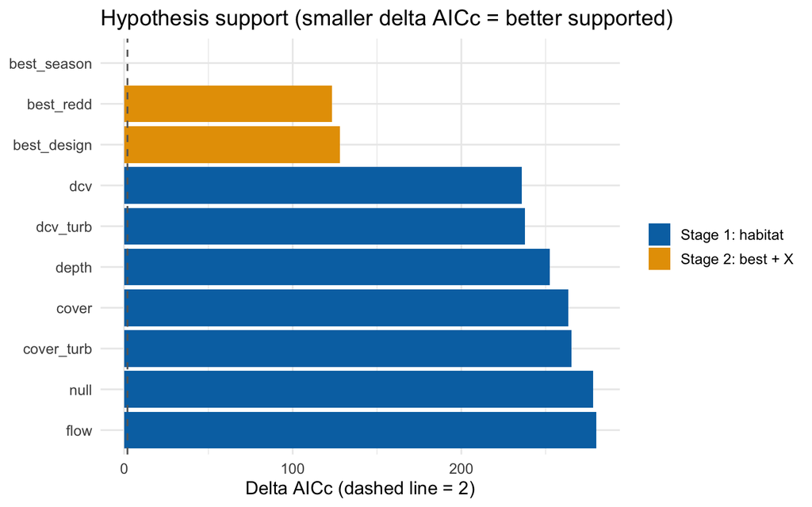

```r
main$table |>
  mutate(model = fct_reorder(model, -delta_AICc)) |>
  ggplot(aes(delta_AICc, model, fill = factor(stage))) +
  geom_col() +
  geom_vline(xintercept = 2, linetype = 2, color = "grey40") +
  scale_fill_manual(values = c("1" = "#0072B2", "2" = "#E69F00"),
                    labels = c("1" = "Stage 1: habitat", "2" = "Stage 2: best + X"),
                    name = NULL) +
  labs(x = "Delta AICc (dashed line = 2)", y = NULL,
       title = "Hypothesis support (smaller delta AICc = better supported)")
```

Models within about 2 delta AICc of the top model are treated as similarly supported. The null model appears in the table so it is clear whether any habitat hypothesis beats intercept-only.

With 223 presences, the largest model fit (13 parameters) has roughly 17.2 events per parameter; the usual guideline is at least 10.

## Best model

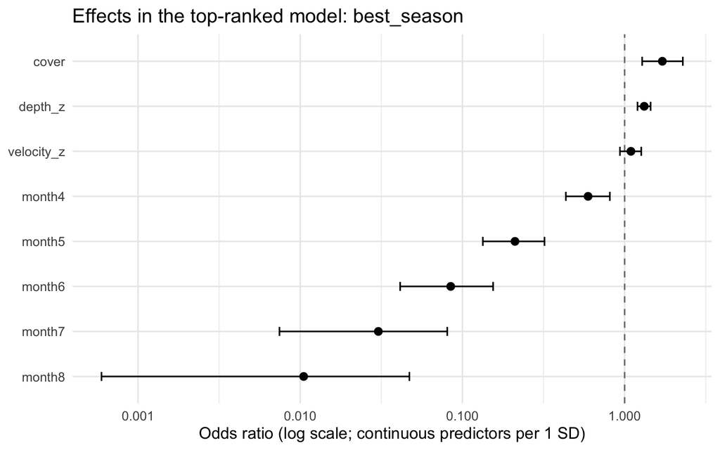

```r
best_name <- main$table$model[1]
best_model <- main$models[[best_name]]

effects_df <- broom::tidy(best_model, conf.int = TRUE, exponentiate = TRUE) |>
  filter(term != "(Intercept)")

effects_df |>
  mutate(term = fct_reorder(term, estimate)) |>
  ggplot(aes(estimate, term)) +
  geom_vline(xintercept = 1, linetype = 2, color = "grey50") +
  geom_point(size = 2.5) +
  geom_errorbarh(aes(xmin = conf.low, xmax = conf.high), height = 0.2) +
  scale_x_log10() +
  labs(x = "Odds ratio (log scale; continuous predictors per 1 SD)", y = NULL,
       title = paste("Effects in the top-ranked model:", best_name))
```

## Predictive performance

AUC is computed with **leave-one-site-out** cross-validation: each site’s units are predicted by a model fit to all the other sites. This replaces in-sample AUC, which rewards model size and site-specific intercepts. Log loss is the mean negative log-likelihood of held-out units (lower is better).

```r
cv_site <- function(rhs, data, group = "location") {
  f <- as.formula(paste("presence ~", rhs))
  pred <- rep(NA_real_, nrow(data))
  for (g in unique(data[[group]])) {
    test <- data[[group]] == g
    p <- tryCatch({
      m <- suppressWarnings(glm(f, data = data[!test, ], family = binomial))
      as.numeric(predict(m, newdata = data[test, ], type = "response"))
    }, error = function(e) rep(NA_real_, sum(test)))
    pred[test] <- p
  }
  ok <- !is.na(pred)
  eps <- 1e-6
  p_clip <- pmin(pmax(pred[ok], eps), 1 - eps)
  tibble(
    n_scored = sum(ok),
    auc_cv = as.numeric(pROC::auc(pROC::roc(data$presence[ok], pred[ok], quiet = TRUE))),
    log_loss = -mean(data$presence[ok] * log(p_clip) + (1 - data$presence[ok]) * log(1 - p_clip))
  )
}

if (params$cv_models) {
  cv_results <- imap_dfr(main$rhs, ~ cv_site(.x, model_data) |> mutate(model = .y)) |>
    left_join(main$table |> select(model, AICc, delta_AICc), by = "model") |>
    arrange(AICc) |>
    mutate(across(c(auc_cv, log_loss, AICc, delta_AICc), ~ round(.x, 3)))

  knitr::kable(cv_results, caption = "Leave-one-site-out cross-validation, ordered by AICc")
}
```

Leave-one-site-out cross-validation, ordered by AICc

| n_scored | auc_cv | log_loss | model | AICc | delta_AICc |
| --- | --- | --- | --- | --- | --- |
| 8415 | 0.775 | 0.113 | best_season | 1783.180 | 0.000 |
| 8415 | 0.698 | 0.119 | best_redd | 1906.336 | 123.156 |
| 8093 | 0.688 | 0.120 | best_design | 1911.031 | 127.851 |
| 8415 | 0.542 | 0.123 | dcv | 2019.011 | 235.831 |
| 8415 | 0.535 | 0.123 | dcv_turb | 2020.915 | 237.735 |
| 8415 | 0.488 | 0.123 | depth | 2035.526 | 252.347 |
| 8415 | 0.447 | 0.123 | cover | 2046.673 | 263.494 |
| 8415 | 0.440 | 0.124 | cover_turb | 2048.531 | 265.351 |
| 8415 | 0.742 | 0.124 | null | 2061.285 | 278.106 |
| 8415 | 0.752 | 0.125 | flow | 2063.273 | 280.093 |

### Confusion matrix of the top model

Presences are rare, so the threshold is set to the observed prevalence rather than 0.5.

```r
best_pred <- predict(best_model, type = "response")
thr <- mean(model_data$presence)
conf <- table(Predicted = as.integer(best_pred > thr), Observed = model_data$presence)
conf
```

```
##          Observed
## Predicted    0    1
##         0 5197   31
##         1 2995  192
```

```r
tibble(threshold = round(thr, 3),
       sensitivity = round(conf["1", "1"] / sum(conf[, "1"]), 3),
       specificity = round(conf["0", "0"] / sum(conf[, "0"]), 3)) |>
  knitr::kable(caption = "In-sample classification at the prevalence threshold")
```

In-sample classification at the prevalence threshold

| threshold | sensitivity | specificity |
| --- | --- | --- |
| 0.027 | 0.861 | 0.634 |

## Robustness checks

### Survey-event random intercept

About 36 units are sampled per survey (`location_table_id`) and are not independent. The whole set is refit with `(1 | location_table_id)` in every model, including the null. If the ranking is similar, conclusions do not depend on ignoring the clustering.

```r
robust_re <- fit_set(model_data, specs_main, random = "(1 | location_table_id)")

robust_re$table |>
  select(model, stage, k, AICc, delta_AICc, weight) |>
  mutate(across(c(AICc, delta_AICc), ~ round(.x, 1)), weight = round(weight, 3)) |>
  knitr::kable(caption = paste0("Ranking with a survey-event random intercept (best stage 1 model: ",
                                robust_re$stage1_best, ")"))
```

Ranking with a survey-event random intercept (best stage 1 model: dcv)

| model | stage | k | AICc | delta_AICc | weight |
| --- | --- | --- | --- | --- | --- |
| best_season | 2 | 10 | 1655.7 | 0.0 | 1 |
| best_redd | 2 | 6 | 1702.0 | 46.3 | 0 |
| best_design | 2 | 14 | 1702.1 | 46.5 | 0 |
| dcv | 1 | 5 | 1733.7 | 78.0 | 0 |
| dcv_turb | 1 | 6 | 1735.3 | 79.7 | 0 |
| cover | 1 | 3 | 1746.4 | 90.7 | 0 |
| flow | 1 | 3 | 1746.9 | 91.2 | 0 |
| cover_turb | 1 | 4 | 1747.5 | 91.8 | 0 |
| depth | 1 | 3 | 1748.1 | 92.4 | 0 |
| null | 1 | 2 | 1754.3 | 98.6 | 0 |

```r
left_join(
  main$table |> transmute(model, rank_glm = row_number()),
  robust_re$table |> transmute(model, rank_re = row_number()),
  by = "model"
) |>
  arrange(rank_glm) |>
  knitr::kable(caption = "Model rank without and with the survey-event random intercept")
```

Model rank without and with the survey-event random intercept

| model | rank_glm | rank_re |
| --- | --- | --- |
| best_season | 1 | 1 |
| best_redd | 2 | 2 |
| best_design | 3 | 3 |
| dcv | 4 | 4 |
| dcv_turb | 5 | 5 |
| depth | 6 | 9 |
| cover | 7 | 6 |
| cover_turb | 8 | 8 |
| null | 9 | 10 |
| flow | 10 | 7 |

### Cover definition

The 20% threshold, the “sum” rule and the choice of categories are all assumptions. Two checks follow. They are for judging how much the conclusions depend on those choices, **not** for choosing the best-fitting definition: picking the cover definition by AICc would add another selection step.

**Threshold, combination rule and categories.** The same rows are refit with `classify_ha_cover()` under different settings. “sum” adds the categories (no overlap assumed); “max” uses the largest single category (full overlap assumed). The true value lies between them. “no_boulder” drops boulder, which the earlier analysis treated as substrate rather than cover.

```r
cover_grid <- expand_grid(threshold = c(10, 20, 30),
                          method = c("sum", "max"),
                          categories = c("all", "no_boulder")) |>
  mutate(use = map(categories, ~ if (.x == "all") cover_use else setdiff(cover_use, "boulder"))) |>
  distinct(threshold, method, use, .keep_all = TRUE)

cover_sens <- pmap_dfr(cover_grid, function(threshold, method, categories, use) {
  d <- classify_ha_cover(model_data, threshold = threshold, use = use, method = method)
  m <- list(
    null = glm(presence ~ 1, data = d, family = binomial),
    cover = glm(presence ~ cover, data = d, family = binomial),
    dcv = glm(presence ~ cover + depth_z + velocity_z, data = d, family = binomial)
  )
  tab <- aicc_table(m)
  tibble(threshold, method, categories,
         pct_units_with_cover = round(100 * mean(d$cover), 1),
         cover_odds_ratio = round(exp(coef(m$cover)[["cover"]]), 2),
         dAICc_cover_vs_null = round(tab$AICc[tab$model == "null"] - tab$AICc[tab$model == "cover"], 1),
         AICc_dcv = tab$AICc[tab$model == "dcv"])
}) |>
  mutate(AICc_dcv = round(AICc_dcv - min(AICc_dcv), 1)) |>
  rename(dAICc_dcv_vs_best_def = AICc_dcv)

knitr::kable(cover_sens,
             caption = "Cover definition sensitivity (dAICc_cover_vs_null > 0 means the cover-only model beats the null; dAICc_dcv_vs_best_def is relative to the best row of this table)")
```

Cover definition sensitivity (dAICc_cover_vs_null > 0 means the cover-only model beats the null; dAICc_dcv_vs_best_def is relative to the best row of this table)

| threshold | method | categories | pct_units_with_cover | cover_odds_ratio | dAICc_cover_vs_null | dAICc_dcv_vs_best_def |
| --- | --- | --- | --- | --- | --- | --- |
| 10 | sum | all | 59.5 | 1.79 | 14.0 | 9.8 |
| 10 | sum | no_boulder | 54.6 | 1.66 | 11.1 | 11.1 |
| 10 | max | all | 59.4 | 1.76 | 13.1 | 10.9 |
| 10 | max | no_boulder | 54.5 | 1.63 | 10.3 | 12.2 |
| 20 | sum | all | 44.9 | 1.74 | 14.6 | 9.8 |
| 20 | sum | no_boulder | 40.7 | 1.72 | 14.0 | 8.4 |
| 20 | max | all | 40.6 | 1.90 | 20.3 | 4.4 |
| 20 | max | no_boulder | 36.8 | 1.86 | 18.7 | 3.8 |
| 30 | sum | all | 35.3 | 1.99 | 23.3 | 1.8 |
| 30 | sum | no_boulder | 32.1 | 1.99 | 22.8 | 0.0 |
| 30 | max | all | 30.0 | 1.73 | 13.2 | 13.7 |
| 30 | max | no_boulder | 27.5 | 1.78 | 14.3 | 10.6 |

**Continuous cover.** The combined percent is used as a continuous predictor (`cover_pct_z`) in place of the 0/1 variable:

```r
specs_cont <- stage1_specs(cover_rhs_pct)
sens_cont <- fit_set(model_data, specs_cont)

sens_cont$table |>
  select(model, stage, k, AICc, delta_AICc, weight) |>
  mutate(across(c(AICc, delta_AICc), ~ round(.x, 1)), weight = round(weight, 3)) |>
  knitr::kable(caption = paste0("Ranking with continuous cover percentages (best stage 1 model: ",
                                sens_cont$stage1_best, ")"))
```

Ranking with continuous cover percentages (best stage 1 model: dcv)

| model | stage | k | AICc | delta_AICc | weight |
| --- | --- | --- | --- | --- | --- |
| best_season | 2 | 9 | 1763.5 | 0.0 | 1 |
| best_redd | 2 | 5 | 1896.6 | 133.1 | 0 |
| best_design | 2 | 13 | 1901.8 | 138.3 | 0 |
| dcv | 1 | 4 | 2001.3 | 237.8 | 0 |
| dcv_turb | 1 | 5 | 2003.3 | 239.8 | 0 |
| cover | 1 | 2 | 2028.9 | 265.4 | 0 |
| cover_turb | 1 | 3 | 2030.8 | 267.3 | 0 |
| depth | 1 | 2 | 2035.5 | 272.0 | 0 |
| null | 1 | 1 | 2061.3 | 297.8 | 0 |
| flow | 1 | 2 | 2063.3 | 299.8 | 0 |

## Caveats

- Redd count is a site-level constant from different years than the snorkel surveys, so `best_redd` cannot be separated from site differences.
- Survey-level flow (optional) is tied to channel and month and may act as a proxy for sampling design or season.
- Choosing the best of stage 1 and then adding terms is a selection step. Check whether stage 1 has near-ties before interpreting stage 2.
- Complete cases are taken on the union of variables so AICc is valid; models with fewer variables therefore lose units with missing velocity.
- HA applies the 20% criterion to the share of an area (that already meets depth and velocity criteria) covered by cover features, with an optional 3-foot buffer around features. Here the share is the combined percent recorded for a microhabitat unit, and no buffer is applied.
- Percent cover in the data is recorded in separate in-channel and overhead layers that can overlap in space. “sum” can overstate combined cover and “max” can understate it; the cover definition checks show how much this matters.
- Two HA cover categories (grass/herbaceous, willow and other riparian vegetation) are not measured, and the 0.5 ft minimum for undercut banks is not recorded. Overhanging vegetation is the closest proxy for riparian cover.
- The HA categories come from the State Water Board’s summary of Table 28 of the Habitat Accounting Protocols. The table itself was not available when this was written; check `ha_cover_map` against the final protocol.
- Surface turbidity is zero for most units and may be driven by a few survey days.
- Presence/absence in a snorkel unit reflects detection as well as habitat use. Visibility (turbidity) and number of divers may affect detection.